# paper_figures.Rmd

Ignatius Pang

31 August 2017

## Description

Create the figures for the manuscript. Does not include the network diagrams, these are in a separate script.

## Import library

```r
# install.packages( 'ggpubr')
library(tidyverse)
library(svglite)
library(ggpubr)
```

## Global parameters

```r
#
# figure_file_suffix <- ".tiff"
# figure_file_suffix <- ".svg"
figure_file_suffix <- ".pdf"
options <- commandArgs(trailingOnly = TRUE)

local_base_directory <- "/home/ignatius/PostDoc/2016/Triplet_Motifs/Source"
source( file.path( local_base_directory, "./Common/parameters_file.R") )
```

```
## [1] "is_run_locally =  TRUE"
```

```r
source( file.path ( source_directory_common, 'count_triplet_motifs_helper.R'))
source( file.path ( source_directory, './Figures/paper_figures_helper.R') )

computational_results_directory <- file.path ( local_base_directory, "Results/Bootstrap_p_values")
figures_results_directory       <- file.path ( local_base_directory, "Results/Figures/Graphs" )

plot_background_colour <- "white"   # "#7E4E99" #
axis_text_colour <- "black"  # "#FFC000" #

### Graphic width and heigth for the boxplots of the randomization results. The observed value is shown in a dot.
### This setting is for the poster presentation.
graphic_width <- 5
graphic_height <- 3


# False positive rate for filtering triplet motifs with low counts
false_positive_rates <- 0.02

# List of 15 types of triplet motifs
all_15_types_of_triplet_motifs <- c("pp"
                                    ,"tutu"
                                    ,"pku"
                                    ,"kuku"
                                    ,"ptd"
                                    ,"kdku"
                                    ,"ptu"
                                    ,"tdtd"
                                    ,"pkd"
                                    ,"tdtu"
                                    ,"kdkd"
                                    ,"tuku"
                                    ,"tdku"
                                    ,"tdkd"
                                    ,"tukd")

# Parameter for Figure 5.
max_num_overlapping_triplets_to_show <- 35

# Whether to use log y-axis
is_use_log_y_axis <- TRUE
```

## Find over-represented motifs

Sort triplet motifs by count and get those that are significantly over-represented.

```r
### Motifs that are significant. Sorted in decending order of the number of observed motifs.

negative_interactions_full <- read.table ( file= file.path( computational_results_directory,
                                           "Negative_Genetic_Interactions/Final_Results/full_results_triplet_motifs_costanzo_2016_collated.tab") )

rows_to_include  <-  (negative_interactions_full[, "observed_counts"] >
                        sum ( negative_interactions_full[, "observed_counts"] ) * false_positive_rates)  &
                     (negative_interactions_full[, "enrichment_adj_p_values"]  < 0.05)

rows_to_include <- ifelse ( is.na(rows_to_include), FALSE, rows_to_include)

significant_types_of_motifs <- dplyr::arrange ( negative_interactions_full[rows_to_include, ], desc( observed_counts ) ) %>%
                               dplyr::select ( one_of ( c( "motif_type"))) %>%
                               as.data.frame() %>%
                               t() %>%
                               as.vector()

## Convert motif names to paper format
significant_types_of_motifs <- convert_triplet_motifs_name_to_paper_style( significant_types_of_motifs )

significant_types_of_motifs <- significant_types_of_motifs[ c("pp", "tutu",  "tdp", "pku", "kuku", "pkd" )]
```

## Figure 1a.

Please refer to the script ‘print_triplet_network.R’. This requires Cytoscape to be opened. The figure was manually selected from this network. Please note it takes a long computational time to draw this in Cytoscape.

## Figure 1b.

Please refer to the script ‘print_triplet_network.R’. This requires Cytoscape to be opened. Please note it takes a long computational time to draw this in Cytoscape.

## Figure 1c.

Please refer to the script ‘print_triplet_network.R’. This requires Cytoscape to be opened. After the network was draw, the Spatial Analysis of Functional Enrichment (SAFE) tool was used to draw this figure.

Anastasia Baryshnikova (2016) Systematic Functional Annotation and Visualization of Biological Networks. Cell Systems , Volume 2 , Issue 6 , 412 - 421.

The Gene Ontology Annotation file used is in the following file path: ‘Results/SAFE/go_bp_140819.txt’.

## Figure 2a.

This figure was hand drawn.

## Figure 2b. Six over-represented triplet motifs

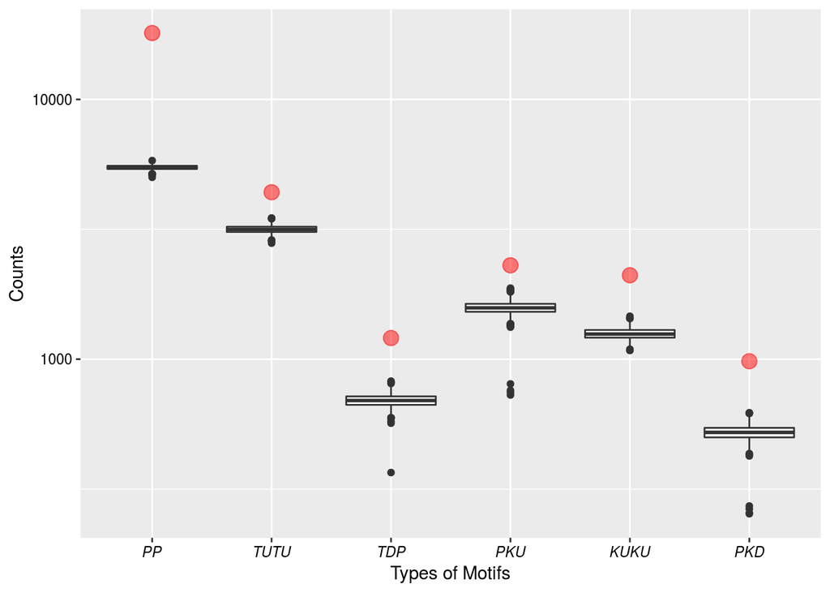

```r
### Print the analysis of negative genetic interactions
negative_interactions_full     <- read.table ( file= file.path( computational_results_directory,
                                               "Negative_Genetic_Interactions/Final_Results/full_results_triplet_motifs_costanzo_2016_collated.tab") )

negative_interactions_full     <- dplyr::arrange ( negative_interactions_full, desc( observed_counts ) )


negative_interactions_random   <- read.table ( file=  file.path( computational_results_directory,
                                                                 "Negative_Genetic_Interactions/Final_Results/randomized_counts_triplet_motifs.tab"  ))

negative_interactions_observed <- read.table ( file= file.path( computational_results_directory,
                                                                "Negative_Genetic_Interactions/Job_21/results_count_triplet_motifs_costanzo.tab"),
                                               header=TRUE )


# head( as.data.frame(negative_interactions_observed) + 1)
# temp_random <- negative_interactions_random
# negative_interactions_random[ is.na(negative_interactions_random)] <- 0
# head( as.data.frame(temp_random) + 1)

print_box_plot_observed_vs_random(negative_interactions_observed, negative_interactions_random, negative_interactions_full, significant_types_of_motifs,
                                  ordering=significant_types_of_motifs, plot_type="boxplot", background_colour=plot_background_colour,
                                  axis_text_colour=axis_text_colour, log_y_axis=is_use_log_y_axis)
```

```r
ggsave(file.path(figures_results_directory, paste( "significant_triplet_motifs_negative_gi", figure_file_suffix, sep="") ),
       plot=last_plot(), width=graphic_width,
       height=graphic_height )
```

## Figure 2c. Paralogs are enriched among the negative genetic interactions of triplet motifs.

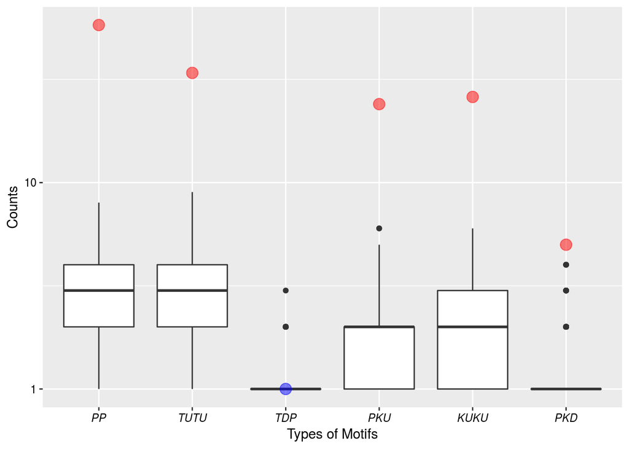

```r
orthomcl_paralogs_full   <- read.table ( file.path( computational_results_directory,
                                                      "Paralogs/Final_Results/full_results_table_orthomcl_paralogs_in_tri_motifs.tab"), header =TRUE)

orthomcl_paralogs_random   <- read.table ( file.path( computational_results_directory,
                                                   "Paralogs/Final_Results/randomized_counts_orthomcl_paralogs_in_tri_motifs.tab"), header =TRUE)
orthomcl_paralogs_observed <- read.table ( file.path( computational_results_directory,
                                                   "Paralogs/Job_1/observed_counts_orthomcl_paralogs_in_tri_motifs.tab"), header =TRUE)


print_box_plot_observed_vs_random(orthomcl_paralogs_observed, orthomcl_paralogs_random, orthomcl_paralogs_full, significant_types_of_motifs,
                                  ordering=significant_types_of_motifs, plot_type="boxplot", background_colour=plot_background_colour,
                                  axis_text_colour=axis_text_colour, log_y_axis=is_use_log_y_axis)
```

```r
ggsave(file.path(figures_results_directory, paste("orthomcl_paralogs", figure_file_suffix, sep="")), plot=last_plot(), width=graphic_width, height=graphic_height )
```

## Figure 3. Random removal or addition of negative genetic interactions highlights the robust over-representation of the six triplet motifs.

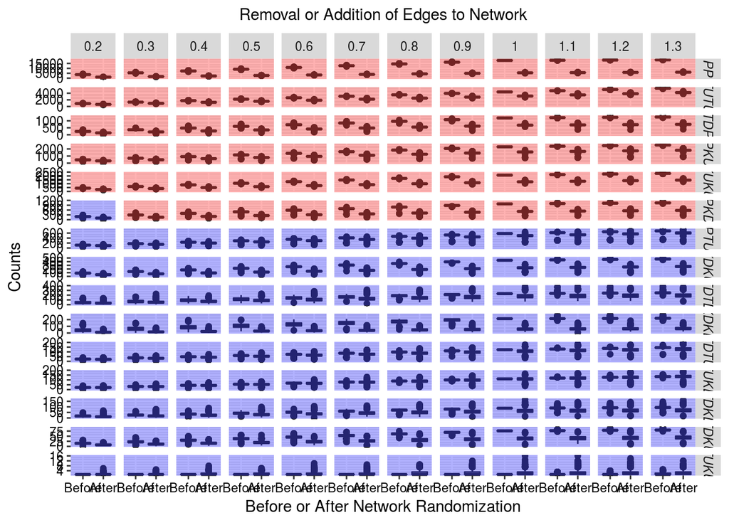

```r
## Randomly add or remove edges

# Need to run collate_random_edges_results.R first

### Directories
final_results_directory <- file.path( computational_results_directory, "Random_Edges/Final_Results")

stat_test_result_random_edges <- read.table ( file=file.path( final_results_directory, "stat_test_result_random_edges.txt" ))

randomization_collated_counts <- read.table (  file=file.path ( final_results_directory, "randomization_collated_counts.txt"))

# The motif types sorted by largest to lowest count
# motif_types_sorted_by_counts_desc <- dplyr::filter ( randomization_collated_counts, parameter==1 & experiment=='Before' & motif_type != 'total' ) %>%
#   dplyr::select( one_of(c('experiment', 'motif_type', 'counts'))) %>%
#   dplyr::arrange(desc(counts)) %>%
#   dplyr::distinct() %>%
#   dplyr::select (one_of(c('motif_type'))) %>%
#   as.data.frame() %>%
#   t() %>%
#   as.vector()

# The motif types are set according to this list
motif_types_sorted_by_counts_desc <- c( "PP", "TUTU", "TDP", "PKU",  "KUKU",  "PKD",
                                        "PTU", "KDKU", "TDTD", "KDKD", "TDTU", "TUKD", "TDKD", "TDKU", "TUKU" )

### Get statistical significance of results
background_shading_table <- dplyr::select(stat_test_result_random_edges, one_of(c('parameter', 'motif_type', 'is_significant')))
background_shading_table$experiment <-1
background_shading_table$counts <-1
background_shading_table[, 'is_significant'] <- as.factor(background_shading_table[, 'is_significant'] )

## Change the order in which the motif types are ordered when they appear as rows in the facet grid
background_shading_table[, 'motif_type'] <- factor (  background_shading_table[, 'motif_type'], levels = motif_types_sorted_by_counts_desc )
randomization_collated_counts[, 'motif_type'] <- factor ( randomization_collated_counts[,'motif_type'], levels = motif_types_sorted_by_counts_desc )
randomization_collated_counts[, 'experiment'] <- factor ( randomization_collated_counts[,'experiment'], levels = c( 'Before', 'After') )


# removal or addition of nodes to network
randomization_collated_counts %>%
    dplyr::filter (  motif_type != 'total' ) %>%
    ggplot (  aes( experiment, counts) ) +
    geom_boxplot()  +
    geom_rect(data = background_shading_table ,aes(  fill=is_significant ),
              xmin = -Inf,xmax = Inf,
              ymin = -Inf,ymax = Inf,alpha = 0.3) +
    scale_fill_manual( values=c('blue', 'red')) +
    facet_grid(   motif_type ~ parameter , scales="free") +
    labs( title = "Removal or Addition of Edges to Network") +
    xlab( "Before or After Network Randomization") +
    ylab ('Counts') +
    theme( plot.background = element_rect(fill = "white", color="white"),
           axis.text = element_text(colour = "black"),
           axis.title = element_text(colour = "black"),
           strip.text.y = element_text(face = "italic"),
           plot.title = element_text(hjust = 0.5, size = rel(1), colour = "black"),
           legend.position="none")
```

```r
ggsave(file.path(figures_results_directory, paste("randomization_collated_results", figure_file_suffix, sep="")),
       plot=last_plot(), width=10, height=10 )
ggsave(file.path(figures_results_directory, paste("randomization_collated_results_15x15", figure_file_suffix, sep="")), plot=last_plot(), width=15, height=15 )
```

## Figure 4a.

This figure was hand drawn.

## Figure 4b. Overlap of negative genetic interactions in triplet motifs with other types of interactions.

```r
final_results_directory <- file.path( computational_results_directory, "Analyze_GI_edges/Final_Results")

triplet_motifs_full_results_file     <- "full_results_table_analyze_gi_edge_in_tri_motifs.tab"
count_triplet_motifs_randomized_file <- "randomized_results_table.tab"

joined_table_summarized_filtered <- read.table (  file=file.path( final_results_directory, triplet_motifs_full_results_file), header = TRUE  )

analyze_gi_edges_counts_gathered <- read.table ( file=file.path( final_results_directory, count_triplet_motifs_randomized_file), header = TRUE )

motif_type_levels_order <- c( 'PP', 'TUTU', 'TDP', 'PKU', 'KUKU', 'PKD')

edge_type_levels_order  <- c( 'None', 'P', 'K1', 'K2', 'T1', 'T2')

joined_table_summarized_filtered[, "motif_type"] <- factor ( joined_table_summarized_filtered[,"motif_type"], levels=motif_type_levels_order)
analyze_gi_edges_counts_gathered[, "motif_type"] <- factor ( analyze_gi_edges_counts_gathered[,"motif_type"], levels=motif_type_levels_order)

joined_table_summarized_filtered[, "edge_type"] <- factor ( joined_table_summarized_filtered[,"edge_type"], levels=edge_type_levels_order)
analyze_gi_edges_counts_gathered[, "edge_type"] <- factor ( analyze_gi_edges_counts_gathered[,"edge_type"], levels=edge_type_levels_order)

analyze_gi_edges_counts_gathered <- dplyr::mutate( analyze_gi_edges_counts_gathered, counts = ifelse( is.na(counts), 1, counts+1) )

joined_table_summarized_filtered <- dplyr::mutate( joined_table_summarized_filtered, observed_counts = observed_counts +1)


ggplot_analyze_gi_edges <- ggplot(analyze_gi_edges_counts_gathered, aes(edge_type, counts))


if (is_use_log_y_axis == TRUE ) {

    ggplot_analyze_gi_edges <- ggplot_analyze_gi_edges + scale_y_log10()
}

ggplot_analyze_gi_edges <- ggplot_analyze_gi_edges +
    geom_boxplot( width = 6) +  # The width parameter changes the width of the boxplot and how the boxplot bunch up together.
    ## Add the observed values as additional points
    geom_point( data=joined_table_summarized_filtered, aes(x=edge_type, y=observed_counts, color=color ),
                 size=4 , alpha=0.5)    +
    scale_color_identity()


### With wrapping
ggplot_analyze_gi_edges <- ggplot_analyze_gi_edges +
    ## Add faceting
    facet_wrap ( ~ motif_type, scales="free") +
    xlab( "Types of Motifs")    +
    ylab( "Counts") +
    theme( axis.text.x=element_text(face="italic") ,  strip.text.x=element_text(face="italic"),
           text = element_text(size=20)
           )  +
    scale_x_discrete( )

ggsave(file.path(figures_results_directory, paste( "analyze_gi_edges_wrap", figure_file_suffix, sep="")),
       plot=ggplot_analyze_gi_edges, width=10.3, height=7.5 ) # , width=10, height=7
```

## Figure 5a. Genetic interactions shared by two or more overlapping triplets highlight functional interaction modules .

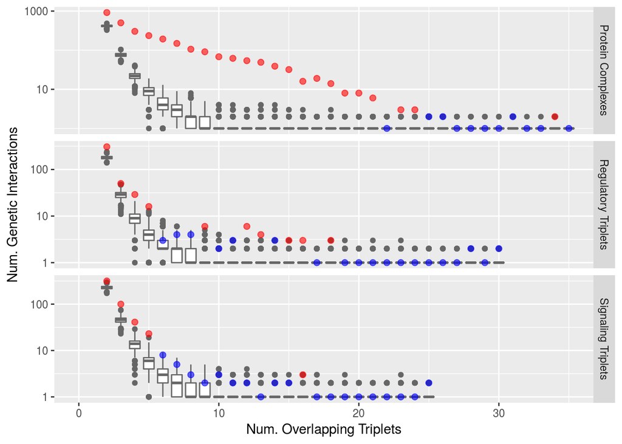

```r
randomized_table <- read.table(  file.path( computational_results_directory, "Repeated_GI_in_Motifs_Freq_Dist/Final_Results/overlapping_triplets_randomized_frequency_distribution.txt"),
                                 header=TRUE)

statistical_analysis <- read.table(  file.path( computational_results_directory, "Repeated_GI_in_Motifs_Freq_Dist/Final_Results/overlapping_triplets_frequency_distribution.txt"),
                                     header = TRUE)

## The maximum number of overlapping triplets for each gi to show (e.g. highest nubmer of overlaps)
statistical_analysis <- dplyr::filter( statistical_analysis, counts <= max_num_overlapping_triplets_to_show)

## Draw counts distribution table
randomized_table %>%
    dplyr::filter( counts <= max_num_overlapping_triplets_to_show ) %>%
    dplyr::mutate( total_count = total_count + 1) %>%
    dplyr::filter( motif_type != 'Others') %>%
    ggplot( aes( counts, total_count, group=counts ) ) +
    geom_boxplot(color="grey40") +
    scale_y_log10() +
    xlab(label="Num. Overlapping Triplets") +
    ylab(label="Num. Genetic Interactions") +
    geom_point( data=statistical_analysis, aes( color=is_significant_color), color=statistical_analysis$is_significant_color,
                alpha=0.6, size=2) +
    coord_cartesian(xlim=c(0, max_num_overlapping_triplets_to_show)) +
    guides(color=FALSE) +
    facet_grid ( motif_type ~., scales="free" )
```

```r
ggsave(file.path(figures_results_directory, paste("repeated_gi_num_motifs_per_gi", figure_file_suffix, sep="") ),
       plot=last_plot(), width=5, height=6) # , height=graphic_height
```

## Figure 5c, d, e.

Please refer to the file ‘print_triplet_network_specific_network.Rmd’

## Figure 6. Triplet motifs that have a significant over-representation of:

## Figure 6a. Triplet motifs that have a significant over-representation of a pair of essential proteins involved in negative genetic interactions.

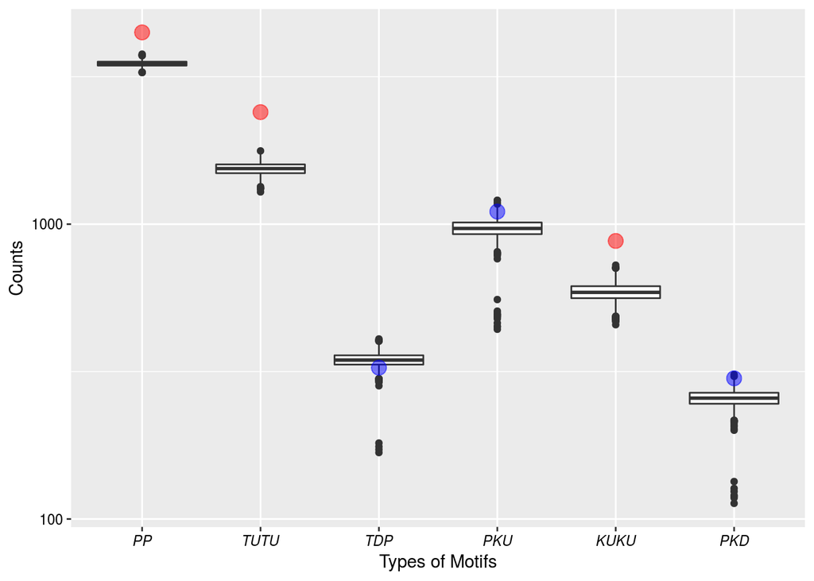

```r
essential_ab_full <- read.table ( file.path( computational_results_directory,
                                             "Negative_GI_Essential/Final_Results/full_results_table_count_a_and_b.tab"), header =TRUE)

essential_ab_random   <- read.table ( file.path( computational_results_directory,
                                                 "Negative_GI_Essential/Final_Results/randomized_results_table_count_a_and_b.tab"), header =TRUE)

essential_ab_observed <- read.table ( file.path( computational_results_directory,
                                                 "Negative_GI_Essential/Job_20/observed_a_and_b_essential_gene_counts.tab"), header =TRUE)

print_box_plot_observed_vs_random(essential_ab_observed, essential_ab_random, essential_ab_full, significant_types_of_motifs,
                                  ordering=significant_types_of_motifs, plot_type="boxplot", background_colour=plot_background_colour,
                                  axis_text_colour=axis_text_colour, log_y_axis=is_use_log_y_axis)
```

```r
ggsave(file.path(figures_results_directory, paste("essential_gene_ab", figure_file_suffix, sep="")), plot=last_plot(), width=graphic_width, height=graphic_height )
```

## Figure 6b. Triplet motifs that have a significant over-representation of an essential third protein not part of the negative genetic interaction in the triplet motif.

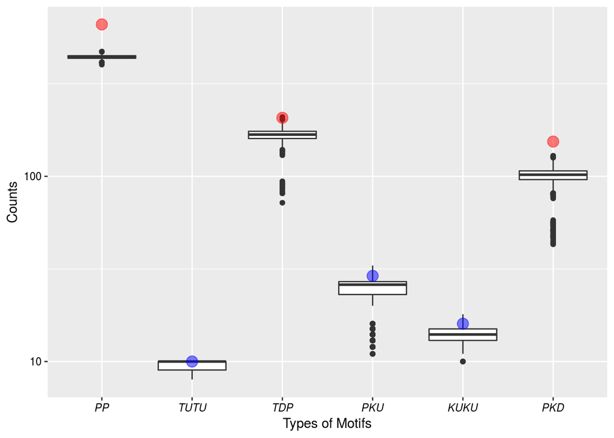

```r
essential_c_full  <- read.table ( file.path( computational_results_directory,
                                                "Negative_GI_Essential/Final_Results/full_results_table_count_c.tab"), header =TRUE)

essential_c_random   <- read.table ( file.path( computational_results_directory,
                                              "Negative_GI_Essential/Final_Results/randomized_results_table_count_c.tab"), header =TRUE)

essential_c_observed <- read.table ( file.path( computational_results_directory,
                                              "Negative_GI_Essential/Job_20/observed_c_essential_gene_counts.tab"), header =TRUE)

print_box_plot_observed_vs_random(essential_c_observed, essential_c_random, essential_c_full, significant_types_of_motifs,
                                  ordering=significant_types_of_motifs, plot_type="boxplot", background_colour=plot_background_colour,
                                  axis_text_colour=axis_text_colour, log_y_axis=is_use_log_y_axis)
```

```r
ggsave(file.path(figures_results_directory, paste("essential_gene_c", figure_file_suffix, sep="")), plot=last_plot(), width=graphic_width, height=graphic_height )
```

## Figure 6c. Triplet motifs that have a significant over-representation of a pair of cell cycle-regulated genes involve in negative genetic interactions

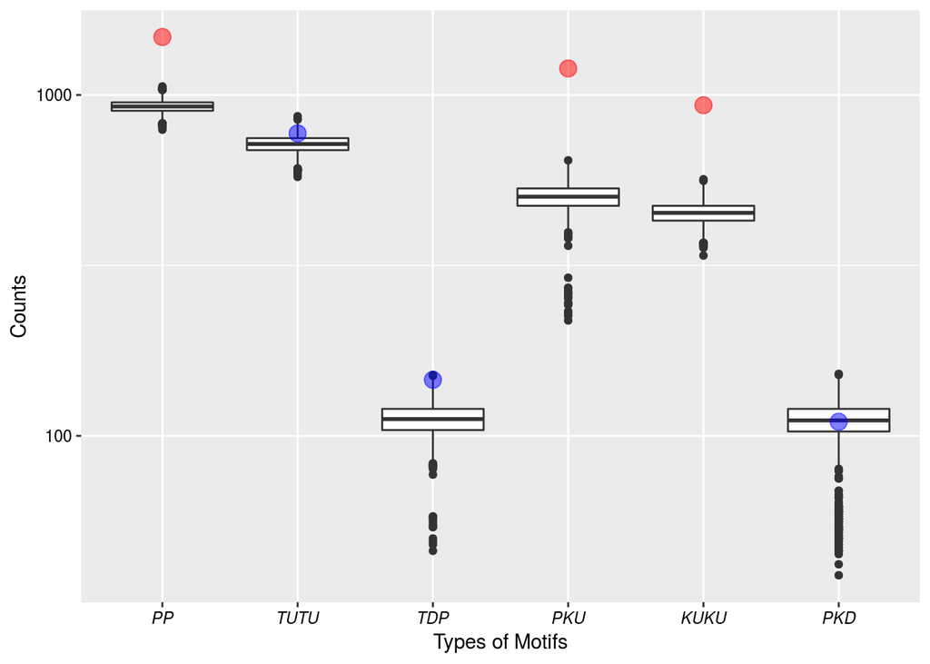

```r
periodic_ab_full <- read.table ( file.path( computational_results_directory,
                                            "Cell_Cycle/Final_Results/full_results_periodic_gene_counts_a_and_b.tab"), header =TRUE)

periodic_ab_random   <- read.table ( file.path( computational_results_directory,
                                                "Cell_Cycle/Final_Results/randomized_results_periodic_gene_counts_a_and_b.tab"), header =TRUE)
periodic_ab_observed <- read.table ( file.path( computational_results_directory,
                                                "Cell_Cycle/Job_1/observed_a_and_b_periodic_gene_counts.tab"), header =TRUE)

print_box_plot_observed_vs_random(periodic_ab_observed, periodic_ab_random, periodic_ab_full, significant_types_of_motifs,
                                  ordering=significant_types_of_motifs, plot_type="boxplot", background_colour=plot_background_colour,
                                  axis_text_colour=axis_text_colour, log_y_axis=is_use_log_y_axis)
```

```r
ggsave(file.path(figures_results_directory, paste("periodic_ab", figure_file_suffix, sep="")), plot=last_plot(), width=graphic_width, height=graphic_height )
```

## Figure 6d. Triplet motifs that have a significant over-representation of a cell cycle-regulated protein not part of the negative genetic interaction in the triplet motif

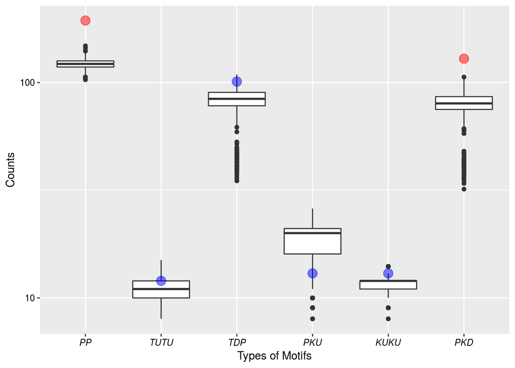

```r
periodic_c_full <- read.table ( file.path( computational_results_directory,
                                            "Cell_Cycle/Final_Results/full_results_periodic_gene_counts_c.tab"), header =TRUE)

periodic_c_random   <- read.table ( file.path( computational_results_directory,
                                                "Cell_Cycle/Final_Results/randomized_results_periodic_gene_counts_c.tab"), header =TRUE)
periodic_c_observed <- read.table ( file.path( computational_results_directory,
                                                "Cell_Cycle/Job_1/observed_c_periodic_gene_counts.tab"), header =TRUE)

print_box_plot_observed_vs_random(periodic_c_observed, periodic_c_random, periodic_c_full, significant_types_of_motifs,
                                  ordering=significant_types_of_motifs, plot_type="boxplot", background_colour=plot_background_colour,
                                  axis_text_colour=axis_text_colour, log_y_axis=is_use_log_y_axis)
```

```r
ggsave(file.path(figures_results_directory, paste("periodic_c", figure_file_suffix, sep="")), plot=last_plot(), width=graphic_width, height=graphic_height )
```

## Figure 6e. Triplet motifs that have a significant over-representation of a pair of proteins that are toxic upon overexpression and involved in negative genetic interaction.

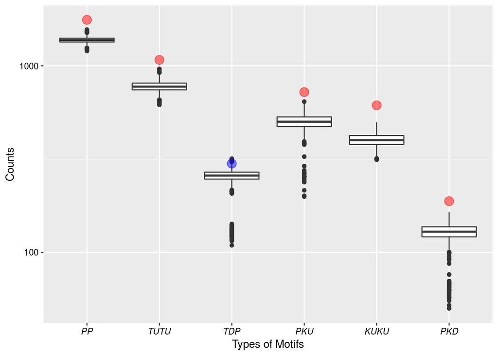

```r
overexpression_ab_full <- read.table ( file.path( computational_results_directory,
                                      "Overexpressed_Toxic_Genes/Final_Results/full_results_table_overexpressed_toxic_gene_counts_a_and_b.tab"), header =TRUE)

overexpression_ab_random   <- read.table ( file.path( computational_results_directory,
                                          "Overexpressed_Toxic_Genes/Final_Results/randomized_results_table_overexpressed_toxic_gene_counts_a_and_b.tab"), header =TRUE)

overexpression_ab_observed <- read.table ( file.path( computational_results_directory,
                                                "Overexpressed_Toxic_Genes/Job_1/observed_a_and_b_overexpressed_toxic_gene_counts.tab"), header =TRUE)

print_box_plot_observed_vs_random(overexpression_ab_observed, overexpression_ab_random, overexpression_ab_full, significant_types_of_motifs,
                                  ordering=significant_types_of_motifs, plot_type="boxplot", background_colour=plot_background_colour,
                                  axis_text_colour=axis_text_colour, log_y_axis=is_use_log_y_axis)
```

```r
ggsave(file.path(figures_results_directory, paste("overexpression_ab", figure_file_suffix, sep="")), plot=last_plot(), width=graphic_width, height=graphic_height )
```

## Figure 6f. Triplet motifs that have a significant over-representation of a protein that is toxic upon overexpression and not part of the negative genetic interaction in the triplet motif.

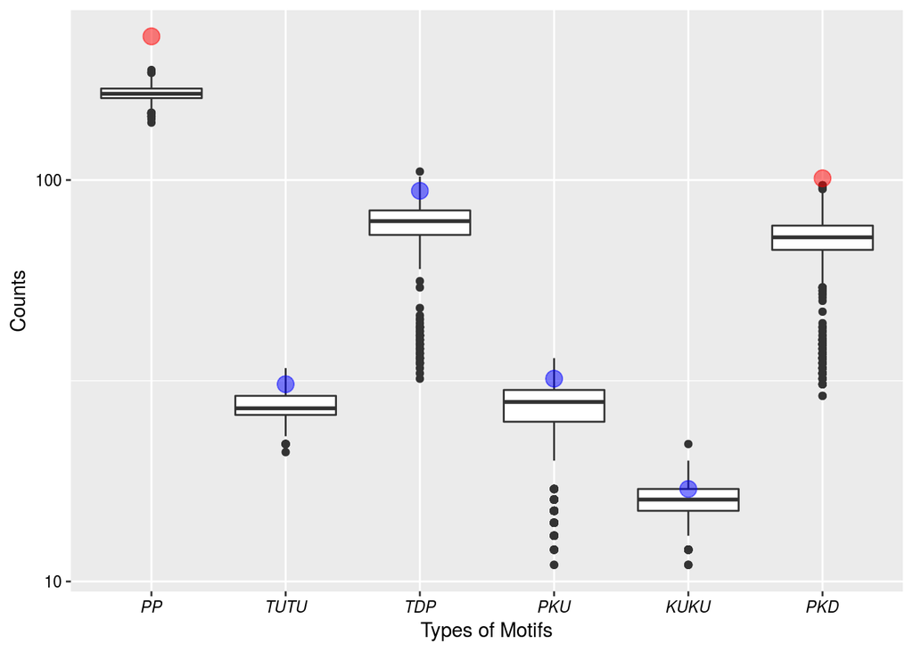

```r
overexpression_c_full <- read.table ( file.path( computational_results_directory,
                                           "Overexpressed_Toxic_Genes/Final_Results/full_results_table_overexpressed_toxic_gene_counts_c.tab"),
                                           header =TRUE)

overexpression_c_random   <- read.table ( file.path( computational_results_directory,
                                          "Overexpressed_Toxic_Genes/Final_Results/randomized_results_table_overexpressed_toxic_gene_counts_c.tab"),
                                          header =TRUE)

overexpression_c_observed <- read.table ( file.path( computational_results_directory,
                                               "Overexpressed_Toxic_Genes/Job_1/observed_c_overexpressed_toxic_gene_counts.tab"), header =TRUE)

print_box_plot_observed_vs_random(overexpression_c_observed, overexpression_c_random, overexpression_c_full, significant_types_of_motifs,
                                  ordering=significant_types_of_motifs, plot_type="boxplot", background_colour=plot_background_colour,
                                  log_y_axis=is_use_log_y_axis )
```

```r
ggsave(file.path(figures_results_directory, paste("overexpression_c", figure_file_suffix, sep="")), plot=last_plot(), width=graphic_width, height=graphic_height )
```

## Figure 7.

Please refer to the file ‘print_triplet_network_specific_network.Rmd’

## Supplementary Figure 1. Frequency of triplet motifs where all three proteins in the triplet share the same GO slim term.

```r
full_results_file_list <- Sys.glob ( paste ( computational_results_directory,
                                         "/GO_Terms_*/Final_Results/full_results_table_*_in_tri_motifs.tab", sep="")  )

random_results_file_list <- Sys.glob ( paste( computational_results_directory,
                                                                 "/GO_Terms_*/Final_Results/randomized_counts_*_in_tri_motifs.tab", sep=""  ) )

observed_results_file_list <- Sys.glob ( paste( computational_results_directory,
                                                                "/GO_Terms_*/Job_20/observed_counts_go_terms*_in_tri_motifs.tab", sep="" ))

list_of_go_types <- factor( c("Biological\nProcess", "Cellular\nComponent", "Molecular\nFunction") )

input_list <- list( full_results_file_list,
             random_results_file_list,
             observed_results_file_list)

## Test number of input files in each element of the 'input_list' object,
## They should all have the same length
map ( input_list, length)
```

```
## [[1]]
## [1] 3
##
## [[2]]
## [1] 3
##
## [[3]]
## [1] 3
```

```r
output_file_name <- file.path(figures_results_directory, paste( "significant_gene_ontology_all", figure_file_suffix, sep="") )

result_list <- combine_graphs_using_faceting ( input_list, list_of_go_types, sort_facet_decreasing=FALSE)

motif_type_significance_box_plot_vertical_stack_faceting( result_list$observed_data,
                                                          result_list$random_data,
                                                          result_list$is_significant,
                                                          output_file_name, graphic_width, graphic_height*2, log_y_axis = is_use_log_y_axis )
```

## Supplementary Figure 2. Frequency of triplet motifs where all three proteins in the triplet share the same phenotype annotation.

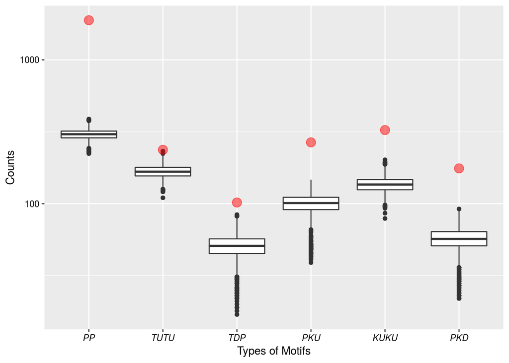

```r
### Print the analysis of negative genetic interactions
negative_interactions_full     <- read.table ( file= file.path( computational_results_directory,
                                               "Phenotype/Final_Results/full_results_table_phenotypes_in_tri_motifs.tab") )

negative_interactions_full     <- dplyr::arrange ( negative_interactions_full, desc( observed_counts ) )


negative_interactions_random   <- read.table ( file=  file.path( computational_results_directory,
                                                                 "Phenotype/Final_Results/randomized_counts_phenotypes_in_tri_motifs.tab"  ))

negative_interactions_observed <- read.table ( file= file.path( computational_results_directory,
                                                                "Phenotype/Job_20/observed_counts_phenotypes_in_tri_motifs.tab"),
                                               header=TRUE )


print_box_plot_observed_vs_random(negative_interactions_observed, negative_interactions_random, negative_interactions_full, significant_types_of_motifs,
                                  ordering=significant_types_of_motifs, plot_type="boxplot", background_colour=plot_background_colour,
                                  axis_text_colour=axis_text_colour, log_y_axis = is_use_log_y_axis )
```

```r
ggsave(file.path(figures_results_directory, paste( "significant_Phenotype", figure_file_suffix, sep="") ),
       plot=last_plot(), width=graphic_width,
       height=graphic_height )
```

## Supplementary Figure 3a.

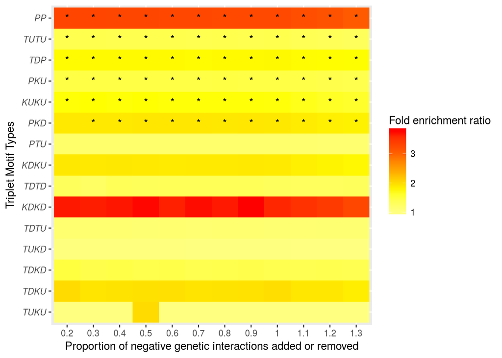

```r
# randomization_collated_counts %>% dplyr::select(one_of(c("motif_type"))) %>% distinct()
# randomization_collated_counts %>% dplyr::filter ( motif_type == "KDKD"  & parameter == 0.2)

motif_types_sorted_by_counts_desc <- c( "PP", "TUTU", "TDP", "PKU",  "KUKU",  "PKD",
                                        "PTU", "KDKU", "TDTD", "KDKD", "TDTU", "TUKD", "TDKD", "TDKU", "TUKU" )

summary_for_heatmap <-  randomization_collated_counts %>%
    dplyr::filter (  is.na(motif_type) == FALSE ) %>%
    tidyr::spread( experiment, counts ) %>%
    dplyr::select( one_of( c( "motif_type", "parameter", "Before", "After"))) %>%
    dplyr::mutate( Before=ifelse(is.na(Before),0, Before),
                   After=ifelse(is.na(After),0, After) ) %>%
    dplyr::group_by( motif_type, parameter ) %>%
    dplyr::summarise ( median_before=median(Before), median_after=median(After) ) %>%
    dplyr::mutate( fold_enrichment_ratio = (median_before + 1)/ (median_after  + 1)) %>%
    dplyr::ungroup()

summary_for_heatmap <- summary_for_heatmap %>%
                                 dplyr::mutate( motif_type = factor(motif_type, levels = rev(motif_types_sorted_by_counts_desc) ),
                                                parameter = factor ( parameter, levels = sort ( unique (parameter ))                     ))

stat_test_result_random_edges <- stat_test_result_random_edges %>%
                                 dplyr::mutate( motif_type = factor(motif_type, levels = rev(motif_types_sorted_by_counts_desc) ),
                                               parameter = factor ( parameter, levels = sort ( unique (parameter )))    ,
                                               is_significant_star = ifelse( is_significant==1, "*", "")  )


ggplot(summary_for_heatmap, aes(y= motif_type, x= parameter )) +
    geom_raster(aes(fill=(fold_enrichment_ratio) ) ) +
    geom_text(data=stat_test_result_random_edges, aes(label=is_significant_star   )) +
    scale_fill_gradientn( colors=rev(heat.colors(5))) + #heat.colors
    theme( axis.text.y = element_text(face = "italic")) +
    guides(fill=guide_colourbar(title="Fold enrichment ratio")) +
    xlab( "Proportion of negative genetic interactions added or removed") +
    ylab ('Triplet Motif Types')
```

```r
ggsave(file.path(figures_results_directory, paste("randomization_collated_results_color_by_fold_enrichment", figure_file_suffix, sep="")), plot=last_plot())
# summary_for_heatmap %>% dplyr::filter ( motif_type == "KDKD"  & parameter == 0.2)
#summary_for_heatmap %>% dplyr::filter ( motif_type == "TUKU"  )
```

## Supplementary Figure 3b.

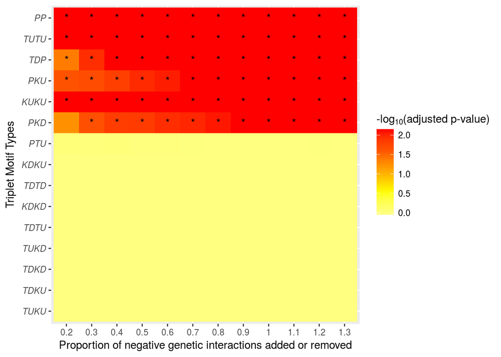

```r
ggplot(stat_test_result_random_edges, aes(y= motif_type, x= parameter )) +
    geom_raster(aes(fill= -log10(boot_n_counts_adj_p_value+ 1/2000*15 ) )) +
    scale_fill_gradientn( colors=rev(heat.colors(5))) + # heat.colors
    theme( axis.text.y = element_text(face = "italic")) +
    guides(fill=guide_colourbar(title=expression("-log"[10]*"(adjusted p-value)"))) +
    geom_text( aes(label=is_significant_star   ))  +
    xlab( "Proportion of negative genetic interactions added or removed") +
    ylab ('Triplet Motif Types')
```

```r
ggsave(file.path(figures_results_directory, paste("randomization_collated_results_color_by_p_values", figure_file_suffix, sep="")), plot=last_plot() )
```

## Supplementary Figure 4. Analyze how filtering the negative genetic interaction by the stringency in fitness score affects the six types of triplet motifs.

```r
full_results_file_list   <- Sys.glob ( "/home/ignatius/PostDoc/2016/Triplet_Motifs/Results/Bootstrap_p_values/More_stringent*/Final_Results/full*")
random_results_file_list <- Sys.glob ( "/home/ignatius/PostDoc/2016/Triplet_Motifs/Results/Bootstrap_p_values/More_stringent*/Final_Results/random*")

list_of_percentiles <- as.numeric( gsub( ".*More_stringent_network_(\\d+).*", "\\1", full_results_file_list) )

observed_results_file_list <- map_chr( list_of_percentiles,
     function(x) {
            paste( "/home/ignatius/PostDoc/2016/Triplet_Motifs/Results/Bootstrap_p_values/More_stringent_network_", x,"/Job_",
                    (x / 5*20),"/results_count_triplet_motifs_costanzo.tab", sep="")
         })

input_list <- list( full_results_file_list,
                    random_results_file_list,
                    observed_results_file_list)

## Test length of inpu
map ( input_list, length)
```

```
## [[1]]
## [1] 20
##
## [[2]]
## [1] 20
##
## [[3]]
## [1] 20
```

```r
results_list <- combine_graphs_using_faceting ( input_list, list_of_percentiles, sort_facet_decreasing=TRUE)

is_significant_tidy <- results_list$is_significant
observed_data_tidy <- results_list$observed_data
random_data_tidy <- results_list$random_data

 significance_color <- sapply ( is_significant_tidy[,"is_significant"], function(x) {  return(boolean_to_colour(x)) } )

 background_colour <- "white"

    return_plot <- ggplot(random_data_tidy, aes(facet_type, value)) +
            geom_boxplot() +
            geom_point( data=observed_data_tidy, aes(x=facet_type, y=value  )   ## Add the observed values as additional points
                        , color=significance_color, size=2 , alpha=0.5)     + # , size=4 , alpha=0.5
            xlab( "Percentage of Negative Genetic Interactions")    +
            ylab( "Counts")  +
            facet_grid( key ~., scales="free") +
            theme( plot.background = element_rect(fill = background_colour, color=background_colour),
                   axis.text = element_text(colour = axis_text_colour),
                   axis.title = element_text(colour = axis_text_colour),
                   strip.text.y=element_text(face="italic"))


    ggsave(file.path(figures_results_directory, paste( "more_stringent_network_all", figure_file_suffix, sep="") ),
       plot=return_plot, width=graphic_width,
       height=graphic_height*2 )
```